# Grammar of graphics

## Geometric layer(s)

In the first lab, we looked at the histogram of `Ozone` from the `airquality` dataset, using base R graphics:

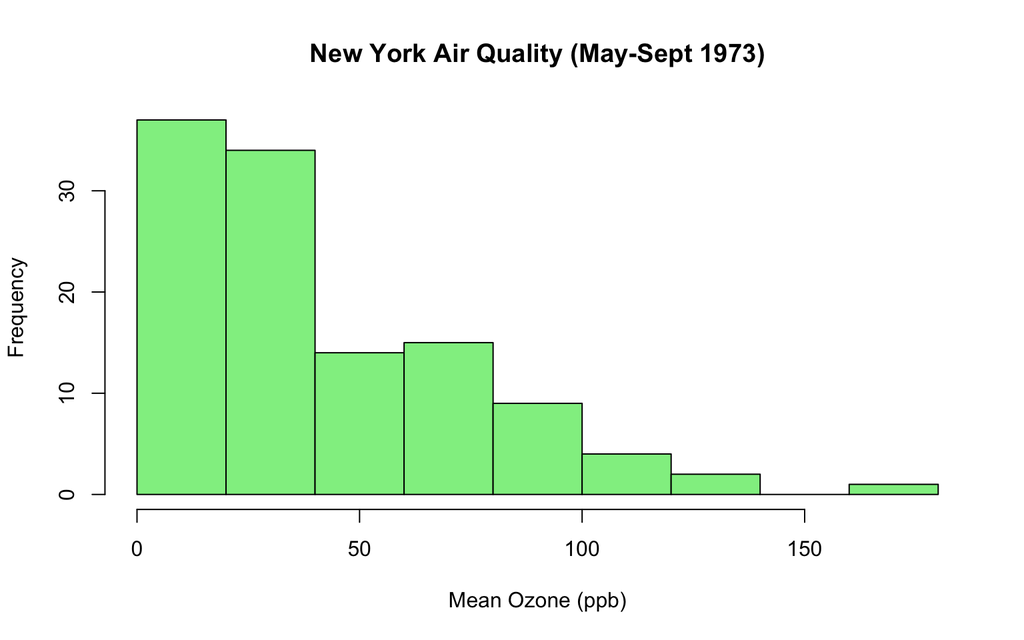

```r
# histogram of `Ozone` in `airquality` using base R plot
hist(airquality$Ozone,
  col = "lightgreen",
  xlab = "Mean Ozone (ppb)",
  main = "New York Air Quality (May-Sept 1973)")
```

Let’s create a histogram of the same data using `ggplot()`. We do this by adding a `geom_histogram()` layer after the canvas, using the `+` operator.

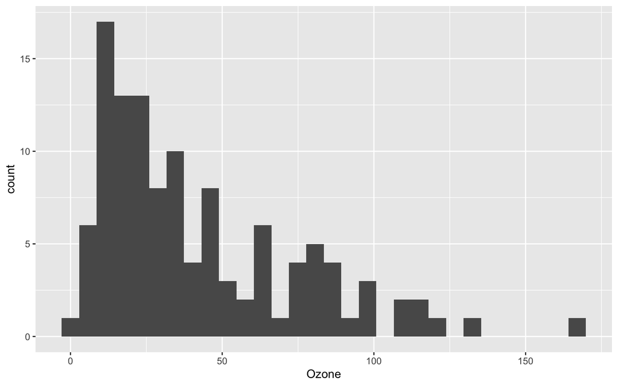

```r
# histogram of `Ozone` in `airquality` using ggplot2
ggplot(airquality, aes(x = Ozone)) +  # create canvas + aes, then
  geom_histogram() # generate a histogram
```

Customize it a bit:

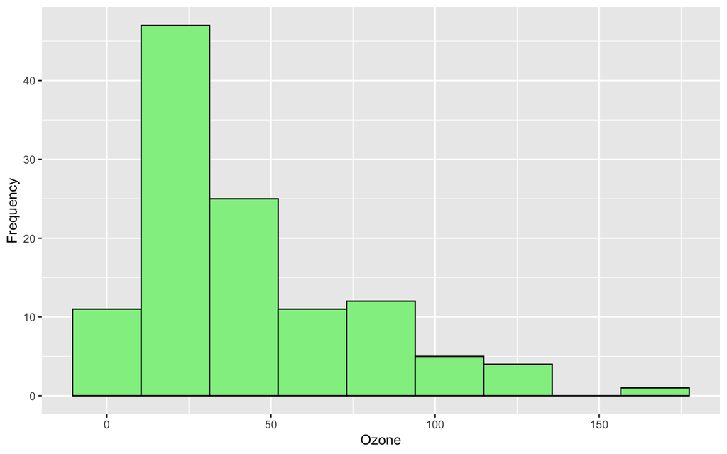

```r
ggplot(airquality, aes(x = Ozone)) + # create canvas + aes, then
  # generate a histogram:
  geom_histogram(fill = "lightgreen", # fill bars
                 colour = "black",    # colour lines
                 bins = 9) +          # no. of bars
                # Or can use binwidth: this defines how thick the bar is.
  ylab("Frequency")  # rename y axis label
```

Geometric layers, or geoms, are defined by the `geom_*()` function. The `ggplot()` package provides a plethora geoms which can automatically map the data defined in `aes()`, into the plots! Try the following:

- `geom_boxplot()`
- `geom_density()`
- `geom_bar()`
- `geom_dotplot()`

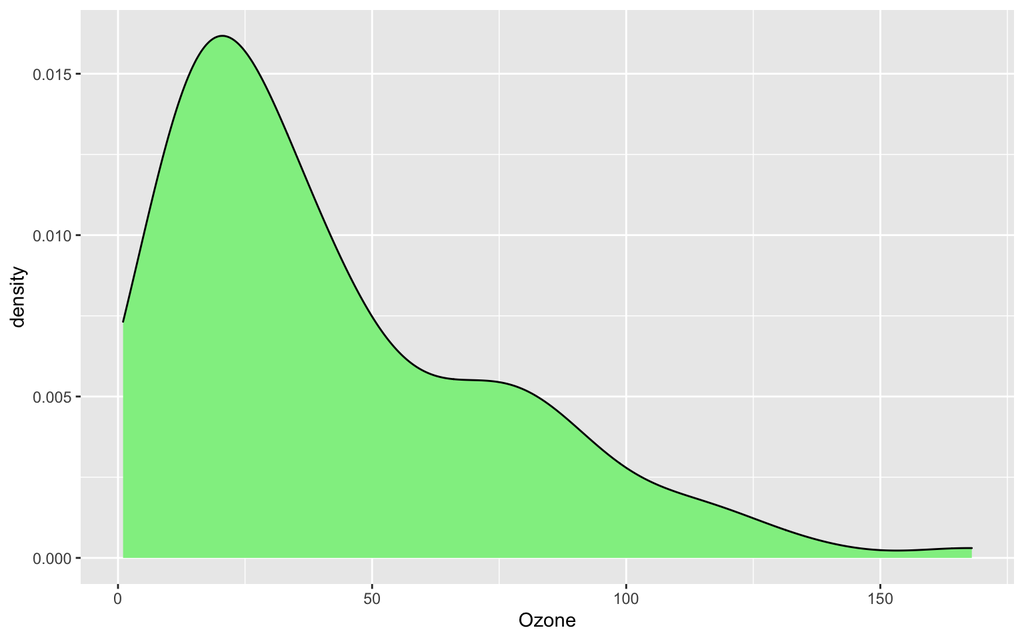

```r
# a density plot using ggplot2:
ggplot(airquality, aes(x = Ozone)) +
  geom_density(fill = "lightgreen")
```

## Multiple layers

We can use different aesthetics, based on the same data, to plot *both* a histogram and a density plot.

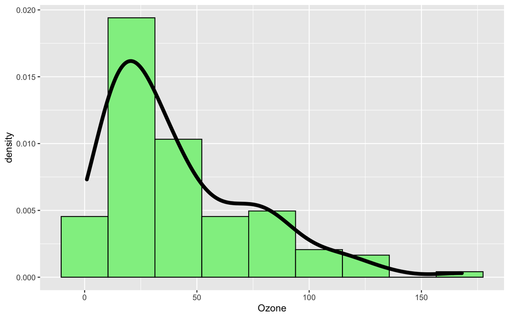

```r
ggplot(airquality) +  # create canvas, then...
  # add histogram, then...
  geom_histogram(aes(x = Ozone, y = ..density..),
                 fill = "lightgreen",
                 colour = "black",
                 bins = 9) + # the magic
  # add density plot layer
  geom_density(aes(x = Ozone),
               size = 2)
```

Reminder: the order of the layer is back + front + fronter + …

## Positioning the aesthetics

The plot above is possible because we can define different aesthetics in each geom. Below is another example using bivariate data from `airquality`.

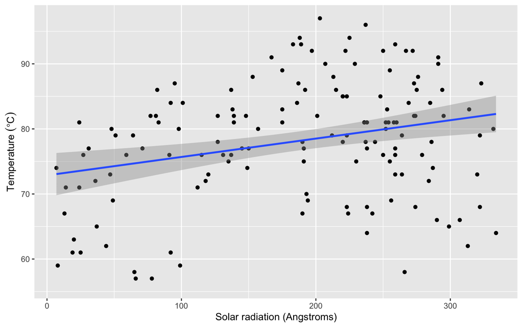

```r
# constructing a scatter plot with best-fit regression line
ggplot(airquality, aes(Solar.R, Temp)) +
  geom_point() +
  geom_smooth(method = "lm") +  # generate linear regression line (lm)
  xlab("Solar radiation (Angstroms)") +  # set x-axis label
  # y-axis label with special character:
  ylab(expression("Temperature " ( degree*C)))
```

All the code below will produce the exact same plot: - Because aesthetics can be on any layout, know it’s flexible.

```r
# move aesthetics to the geoms:
ggplot(airquality) +
  geom_point(aes(Solar.R, Temp)) +
  geom_smooth(aes(Solar.R, Temp),
              method = "lm") +
  xlab("Solar radiation (Angstroms)") +  # set x-axis label
  # y-axis label with special character:
  ylab(expression("Temperature " ( degree*C)))

# move data canvas and aesthetics to the geoms:
ggplot() +
  geom_point(data = airquality, aes(Solar.R, Temp)) +
  geom_smooth(data = airquality, aes(Solar.R, Temp),
              method = "lm") +
  xlab("Solar radiation (Angstroms)") +  # set x-axis label
  # y-axis label with special character:
  ylab(expression("Temperature " ( degree*C)))
```

## Grouping by a third variable (dimensions)

- [Simpson’s paradox](https://en.wikipedia.org/wiki/Simpson%27s_paradox)
  - Basically means data cannot be representative by simply adding up to show something, there are other factors can impact on them.
- To understand whether there are differences between categories of data.

We can use `Month` to group our data by colour in `ggplot2`. However, it is currently a `numeric` variable. Let’s add `Month` as a third aesthetic.

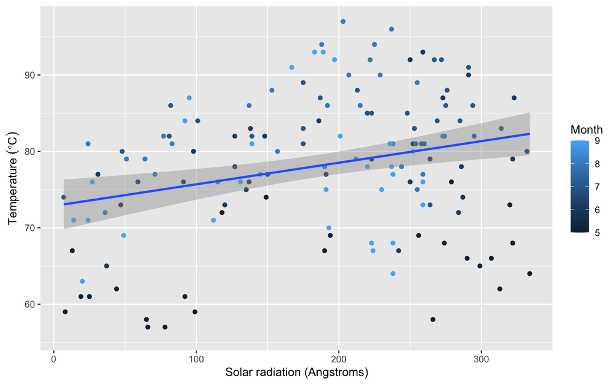

```r
ggplot(airquality, aes(Solar.R, Temp,
                       colour = Month)) +
  geom_point() +
  geom_smooth(method = "lm") +
  xlab("Solar radiation (Angstroms)") +
  ylab(expression("Temperature " ( degree*C)))
```

Because `Month` has been identified as a continuous variable, the plot has not visualised the data “properly”. It is still quite difficult to see differences in the patterns among months.

In the first Lab, we showed that `Month` should be converted to a factor. The reason for doing so is because plots will interpret data differently based on their `class()`.This is the same plot, but with `Month` converted to a variable of class `factor`:

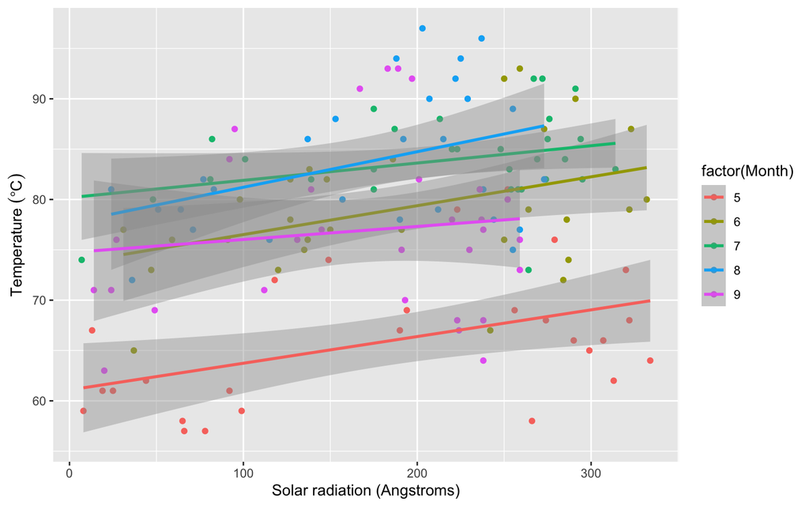

```r
# replot the same visualisation, but now with factor(Month)
ggplot(airquality, aes(Solar.R, Temp,
                       colour = factor(Month))) + # ***
  geom_point() +
  geom_smooth(method = "lm") +
  xlab("Solar radiation (Angstroms)") +
  ylab(expression("Temperature " ( degree*C)))
```

Success! But are we able to look at the plot and easily isolate the raw points?. When using colours or shapes to differentiate groups and the result looks “busy”, it is a good idea to **facet** the plot using `facet_wrap()`.

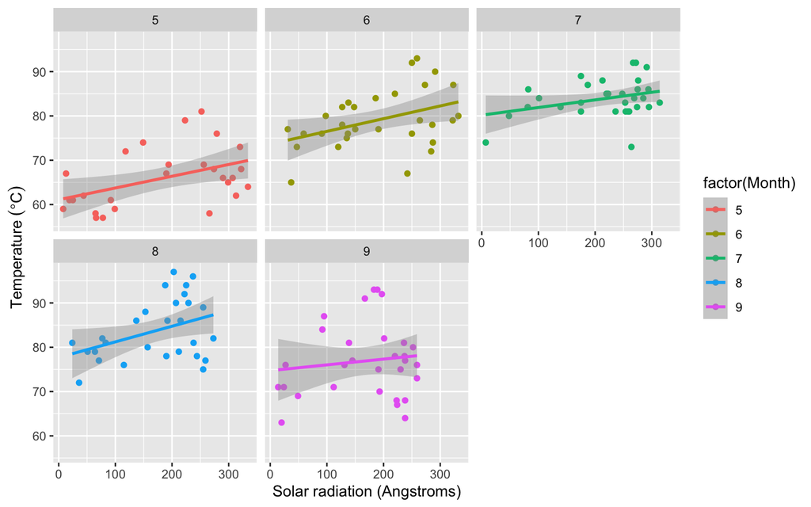

```r
# replot the same visualisation, but now with facet_wrap()
ggplot(airquality, aes(Solar.R, Temp,
                       colour = factor(Month))) + # ***
  geom_point() +
  geom_smooth(method = "lm") +
  xlab("Solar radiation (Angstroms)") +
  ylab(expression("Temperature " ( degree*C))) +
  facet_wrap(~ Month)
```

# Explore: boxplot

We have only scratched the surface of what can be done using `ggplot2`. You will now spend the rest of the lab to explore scales, axes, legends and facets and understand data better.

Create a boxplot using 2 variables: `Ozone` and `Month` with the following conditions:

1. `Ozone` as `y`, and is named appropriately on the axis
2. `Month` as `x`, and is named appropriately on the axis
3. `Month` is renamed to the months May – Sep, instead of numbers
4. `Month` is arranged by date when plotted
5. All boxplots are filled with the colour `"firebrick"`
6. A theme of your choice is applied to the entire plot

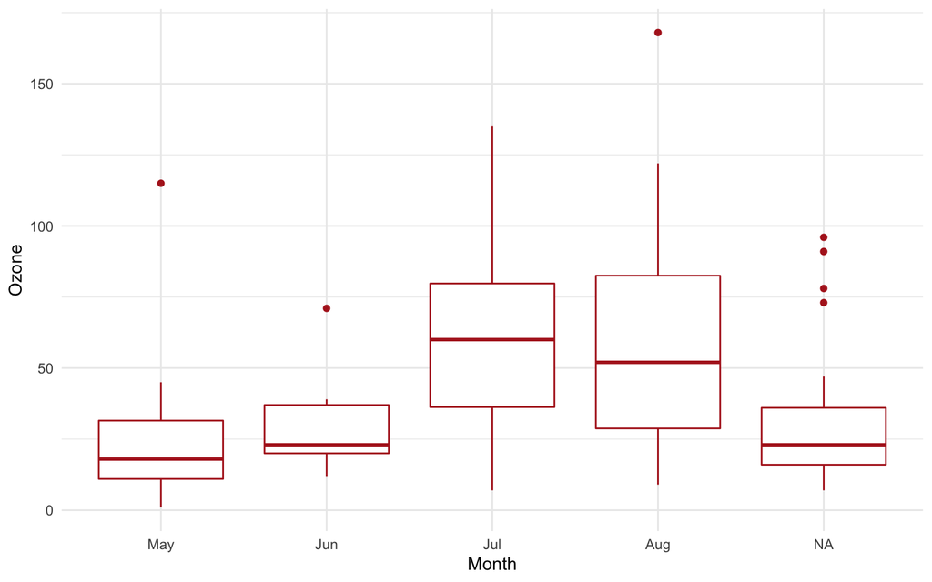

```r
airquality %>%
  mutate(Month = case_when(
    Month == 5 ~ "May",
    Month == 6 ~ "Jun",
    Month == 7 ~ "Jul",
    Month == 8 ~ "Aug",
    Month == 9 ~ "Sept",
  )) %>%
  ggplot(aes(y = Ozone, x = factor(Month,levels = month.abb))) +
  xlab("Month") +
  geom_boxplot(color = "firebrick") +
  theme_minimal()
```

# Explore: multivariate plot

We will improve on the scatterplot that was produced in the Demo: 1. Rename the months from numbers to May – Sep 2. Rename the Legend title from `"factor(Month)"` to `"Month"` 3. Rearrange the facet so that it is wrapped in two columns, not three columns. 4. Instead of a universal scale, make it such that each plot has its own individual y-axis that is scaled for the data. 5. Move the legend from the right side of the canvas to the top.

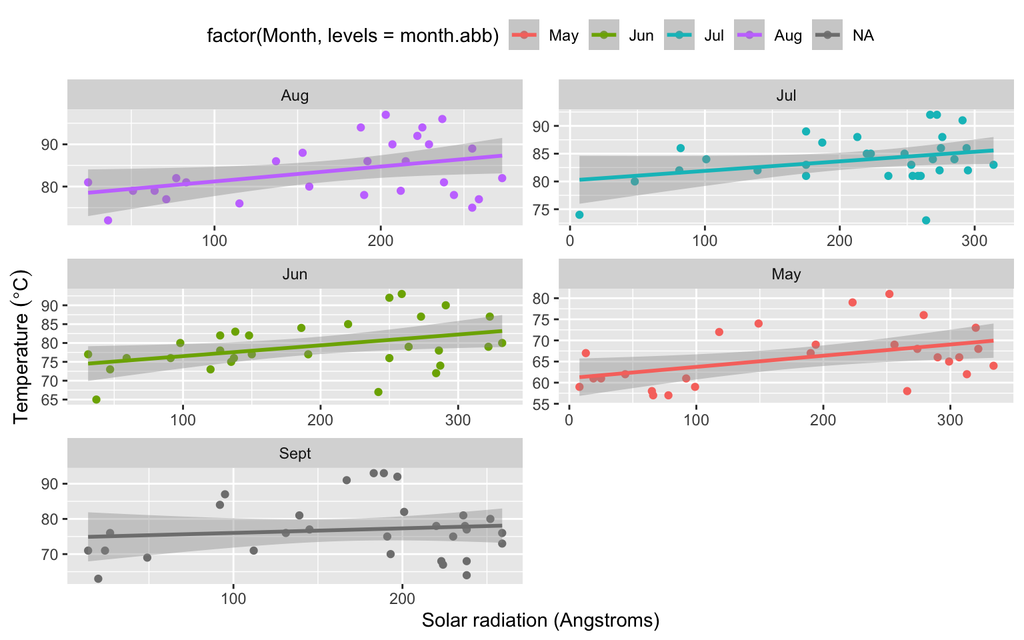

```r
airquality %>%
  mutate(Month = case_when(
    Month == 5 ~ "May",
    Month == 6 ~ "Jun",
    Month == 7 ~ "Jul",
    Month == 8 ~ "Aug",
    Month == 9 ~ "Sept"
  )) %>%
  ggplot(aes(Solar.R, Temp, colour = factor(Month,levels = month.abb))) +
  geom_point() +
  geom_smooth(method = "lm") +
  xlab("Solar radiation (Angstroms)") +
  ylab(expression("Temperature " ( degree*C))) +
  scale_fill_discrete(name = "Month") +
  facet_wrap(~ Month, ncol = 2, scales = "free") +
  theme(legend.position = "top")
```

# Explore: road fatalities

You should have some understanding of how to read `.csv` and `.xlsx` files into R by now. How do you construct your code such that the `read*()` code works when you transfer it to a group member?

Notes:

- Try to understand how file paths work *relative* to an R Markdown file.
- If a data file is in the same folder as your `.Rmd` file, then reading the file is as easy as `read.csv("filename.csv")`.
- If the data file is in a folder, and that folder is in the same folder as your `.Rmd` file (e.g. the “data” folder), then you will need to add the folder path to the code: `read.csv("folder/filename.csv")`
- If the file is an Excel file, then you have to use the `readxl` package and read the file using `read_excel()`.

Read the `AllFatalities.csv` file into R and save it as an object, e.g. `fatalities`.

```r
# read the .csv file `ardd_fatalities_nov2020.csv`

# use this to check if your data file is in the same directory
# as this .Rmd file:
# list.files()

# use this to determine the working directory of
# this .Rmd file:
# getwd()

# example code:
# fatalities <- read.csv("data/AllFatalities.csv")
```

- Investigate the structure of the data. What variables are interesting?
- Use numerical summaries to find interesting observations.
- Use `ggplot2` to visualise interesting patterns.
- List some research questions that can be answered with the `ggplot2` plots.